# Mercari Price Suggestion Challenge

oooooooh!

# Overview

Competition URL：https://www.kaggle.com/c/mercari-price-suggestion-challenge/kernels

時程表：

- February 7, 2018 - Entry deadline. You must accept the competition rules before this date in order to compete.
- February 7, 2018 - Team Merger deadline. This is the last day participants may join or merge teams.
- February 14, 2018 - Final submission deadline. This is the last day participants are allowed to modify Kernels, submit to competition, and to select the Kernel version for Stage 2. After this date, all the Kernels versions are recorded and will be re-run based on the selections.
- February 15, 2018 - Stage 2 evaluation period starts. Sit back and watch the leaderboard.
- February 21, 2018 - Stage 2 ends. Final results announced.

# Exploratory Data Analysis (EDA)

```r
library(stringr)
```

[output not shown]

接下來可以進行簡單的資料觀察

| train_id | name | item_condition_id | category_name | brand_name | price | shipping | item_description |
| --- | --- | --- | --- | --- | --- | --- | --- |
| 0 | MLB Cincinnati Reds T Shirt Size XL | 3 | Men/Tops/T-shirts |  | 10 | 1 | No description yet |
| 1 | Razer BlackWidow Chroma Keyboard | 3 | Electronics/Computers & Tablets/Components & Parts | Razer | 52 | 0 | This keyboard is in great condition and works like it came out of the box. All of the ports are tested and work perfectly. The lights are customizable via the Razer Synapse app on your PC. |
| 2 | AVA-VIV Blouse | 1 | Women/Tops & Blouses/Blouse | Target | 10 | 1 | Adorable top with a hint of lace and a key hole in the back! The pale pink is a 1X, and I also have a 3X available in white! |
| 3 | Leather Horse Statues | 1 | Home/Home Decor/Home Decor Accents |  | 35 | 1 | New with tags. Leather horses. Retail for [rm] each. Stand about a foot high. They are being sold as a pair. Any questions please ask. Free shipping. Just got out of storage |
| 4 | 24K GOLD plated rose | 1 | Women/Jewelry/Necklaces |  | 44 | 0 | Complete with certificate of authenticity |

[output not shown]

[output not shown]

從提供的Overview可以知道欄位定義如下：

- train_id or test_id - the id of the listing
- name - the title of the listing. Note that we have cleaned the data to remove text that look like prices (e.g. $20) to avoid leakage. These removed prices are represented as [rm]
- item_condition_id - the condition of the items provided by the seller
- category_name - category of the listing
- brand_name
- price - the price that the item was sold for. This is the target variable that you will predict. The unit is USD. This column doesn’t exist in test.tsv since that is what you will predict.
- shipping - 1 if shipping fee is paid by seller and 0 by buyer
- item_description - the full description of the item. Note that we have cleaned the data to remove text that look like prices (e.g. $20) to avoid leakage. These removed prices are represented as [rm]

模型為從商品的其他資訊，推測應變數價格price。首先觀察應變數資料：

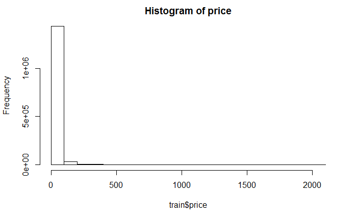

```r
# 觀察price資料分布
hist(train$price, main='Histogram of price')
```

資料嚴重右偏，所以用log(x+1)修正資料，想辦法讓資料偏向常態一點。

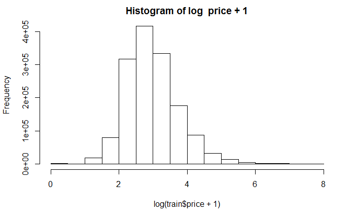

```r
# 取log(price+1)
hist(log(train$price+1), main='Histogram of log  price + 1')
```

資料看起來正常一點了，後面會讓應變數做轉換，提高預測準確率。接下來我們來對其他欄位進行探勘。

## train_id

沒意義的東西就不看了。

## item_condition_id

```r
table(train$item_condition_id)
```

```
     1      2      3      4      5
640549 375479 432161  31962   2384
```

可以看到大部份的資料集中在1，5是最少的。

[output not shown]

```r
aov.item_condition_id <- aov(log_price~ train$item_condition_id)
summary(aov.item_condition_id)
```

```
                             Df Sum Sq Mean Sq F value Pr(>F)
train$item_condition_id       1      4   3.576   6.372 0.0116 *
Residuals               1482533 832165   0.561
---
Signif. codes:  0 ‘***’ 0.001 ‘**’ 0.01 ‘*’ 0.05 ‘.’ 0.1 ‘ ’ 1
```

P-value小於0.05，95%的信心水準下有顯著相關，但不到0.01，這個變數對我們的價格似乎有些微影響。

## category_name

這個欄位資料都是文字，並且分類用“/”符號分隔，每個間隔內容看起來是獨立的，這裡把他當成分類貼標來看，所以需要進行文字探勘將它做拆解。

```r
# 觀察此欄位內容
head(train$category_name,5)
```

```
[1] "Men/Tops/T-shirts"
[2] "Electronics/Computers & Tablets/Components & Parts"
[3] "Women/Tops & Blouses/Blouse"
[4] "Home/Home Decor/Home Decor Accents"
[5] "Women/Jewelry/Necklaces"
```

```r
# 把所有貼標轉換成清單統計結果
category_list<-unlist(strsplit(train$category_name,'/'))
category_df<-as.data.frame(table(category_list))
head(category_df[order(category_df$Freq,decreasing = T),],10)
```

|  | category_list | Freq |
| --- | --- | --- |
| 938 | Women | 683360 |
| 85 | Beauty | 207828 |
| 492 | Kids | 171796 |
| 36 | Athletic Apparel | 134422 |
| 757 | Shoes | 132620 |
| 315 | Electronics | 126318 |
| 544 | Makeup | 124624 |
| 613 | Other | 115592 |
| 863 | Tops & Blouses | 107967 |
| 557 | Men | 95967 |

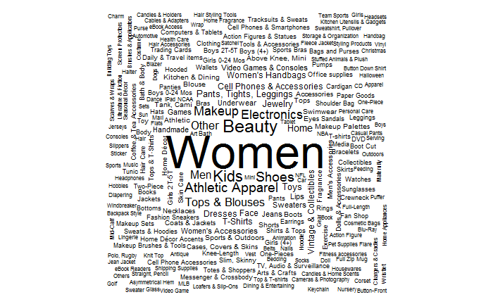

可以看到女生的衣服貼標數量真的很多，比例上來看也高於其他貼標，研判據有資料參考價值，我們來看如果轉成類別會有多少元素。

```
NA
```

```r
# 計算欄位內"/的最大值"
max(str_count(train$category_name, "/"))
```

```
[1] 4
```

可以把每個商品後面加5個欄位，並且根據“/”分隔，將標籤放進去，但是這樣對最後建模沒有太大幫助，最後還是決定轉為950個欄位的稀疏矩陣，比較好對應變數建立模型。

## brand_name

|  | Var1 | Freq |
| --- | --- | --- |
| 1 |  | 632682 |
| 3417 | PINK | 54088 |
| 3111 | Nike | 54043 |
| 4581 | Victoria's Secret | 48036 |
| 2673 | LuLaRoe | 31024 |
| 271 | Apple | 17322 |
| 1648 | FOREVER 21 | 15186 |
| 3121 | Nintendo | 15007 |
| 2681 | Lululemon | 14558 |
| 2885 | Michael Kors | 13928 |

最多的果然是空值，畢竟大多商品不是名牌也是很正常的，在來是PINK、Nike、Victoria’s Secret，難怪女裝會這麼多不是沒有原因的，我們一樣來統計名牌的總數：

```r
nrow(brand_name_df)
```

```
[1] 4810
```

高達4810種名牌，看來是大大小小的名牌都進來了，我們一樣預計將之轉為稀疏矩陣處理。

## shipping

從說明來看似乎跟應變數沒有太大關係，但既然他給了，一定有他的原因，我們一樣做一下多變量分析看一下。

```r
table(train$shipping)
```

```
     0      1
819435 663100
```

```r
aov.shipping <- aov(log_price~ train$shipping)
summary(aov.shipping)
```

```
                    Df Sum Sq Mean Sq F value Pr(>F)
train$shipping       1  43921   43921   82607 <2e-16 ***
Residuals      1482533 788247       1
---
Signif. codes:  0 ‘***’ 0.001 ‘**’ 0.01 ‘*’ 0.05 ‘.’ 0.1 ‘ ’ 1
```

想不到居然有高度相關！我們來看一下統計圖型。

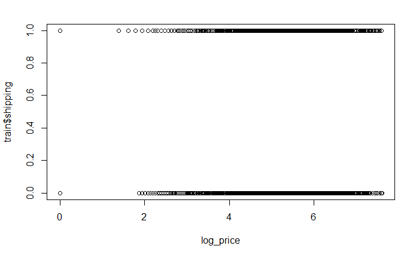

```r
plot(aov.shipping$model)
```

分布上來看確實有些差異在，此因子看來也是重要變數。

## item_description

這個欄位是對商品的敘述，沒有一定的文字結構，如果用文字探勘進行單字統計，可能會非常的發散，所以我們改用字數來決定這個特徵。

| item_description | nchar |
| --- | --- |
| No description yet | 18 |
| This keyboard is in great condition and works like it came out of the box. All of the ports are tested and work perfectly. The lights are customizable via the Razer Synapse app on your PC. | 188 |
| Adorable top with a hint of lace and a key hole in the back! The pale pink is a 1X, and I also have a 3X available in white! | 124 |
| New with tags. Leather horses. Retail for [rm] each. Stand about a foot high. They are being sold as a pair. Any questions please ask. Free shipping. Just got out of storage | 173 |
| Complete with certificate of authenticity | 41 |

```
    Pearson's product-moment correlation

data:  train$price and nchar(train$item_description)
t = 58.663, df = 1482500, p-value < 2.2e-16
alternative hypothesis: true correlation is not equal to 0
95 percent confidence interval:
 0.04651725 0.04972920
sample estimates:
       cor
0.04812335
```

P-value < 0.05 顯著相關，看來商品描述的字數長度會影響我們的商品價格，為了更精確驗證我們的假設，改根據“單字數”進行統計。

```r
# 將統計結果列出來
data.frame(item_description=train$item_description[1:5],nword=nword_itdes[1:5])
```

| item_description | nword |
| --- | --- |
| No description yet | 3 |
| This keyboard is in great condition and works like it came out of the box. All of the ports are tested and work perfectly. The lights are customizable via the Razer Synapse app on your PC. | 36 |
| Adorable top with a hint of lace and a key hole in the back! The pale pink is a 1X, and I also have a 3X available in white! | 29 |
| New with tags. Leather horses. Retail for [rm] each. Stand about a foot high. They are being sold as a pair. Any questions please ask. Free shipping. Just got out of storage | 32 |
| Complete with certificate of authenticity | 5 |

```
    Pearson's product-moment correlation

data:  train$price and nword_itdes
t = 59.197, df = 1482500, p-value < 2.2e-16
alternative hypothesis: true correlation is not equal to 0
95 percent confidence interval:
 0.04695493 0.05016674
sample estimates:
       cor
0.04856096
```

P-value < 0.05 顯著相關，符合我們的假設，後面會以“單字數”進行建模分析，雖然進行細部的文字探勘可以提高模型準確率，但工程浩大所以先到這裡。

## name

同上面的商品敘述一樣，我們將之轉為單字數統計：

```r
# 將統計結果列出來
data.frame(name=train$name[1:5],nword=nword_name[1:5])
```

| name | nword |
| --- | --- |
| MLB Cincinnati Reds T Shirt Size XL | 7 |
| Razer BlackWidow Chroma Keyboard | 4 |
| AVA-VIV Blouse | 2 |
| Leather Horse Statues | 3 |
| 24K GOLD plated rose | 4 |

```
    Pearson's product-moment correlation

data:  train$price and nword_name
t = 42.064, df = 1482500, p-value < 2.2e-16
alternative hypothesis: true correlation is not equal to 0
95 percent confidence interval:
 0.03291863 0.03613419
sample estimates:
      cor
0.0345265
```

P-value < 0.05 顯著相關，看來商品名稱的長度與價格有顯著關係，後面也會以“單字數”進行建模分析。商品名稱的內容通常會影響著價格，但這樣要進行更細部的文字探勘，由於工程耗大所以我們先做到這樣。

# Data processing

從前面EDA來看，我們有了初步建模計劃：

- name：轉為單字數。
- item_condition_id：保留原本值。
- category_name：轉為稀疏矩陣，950個。
- brand_name：轉為稀疏矩陣，4810個。
- shipping：保留原本值。
- item_description：轉為單字數。

我們先來看看怎麼轉稀疏矩陣。